# Zápočtový test 2

# 1. Část - Úlohy na interpretaci výstupů

Využijte *Cars.html*

## Úloha 1

*Která z číselných proměnných má nejsymetričtější rozdělení a jaká je její špičatost v porovnání s normálním rozdělením?*

**Rear.seat.room (Skew)** = 0.07569843  
**Rear.seat.room (Kurt)** = 0.69841  
Nejsymetričtější rozdělení má proměnná **Rear.seat.room** s velmi nepatrným **pozitivním zešikmením**. V porovnání s normálním rozdělením je distribuce této proměnné **špičatější**, s **kurtózou = 0.69841**.

## Úloha 2

*Má větší variabilitu cena vozu nebo počet ujetých mil na 1 gallon paliva (Proměnné Price a MPG.city)? Podle jakého ukazatele se rozhodujete a proč?*

**CoefVar (Price)** = 0.49510965  
**CoefVar (MPG.city)** = 0.25127042  
Větší variabilitu má proměnná **Price**. Rozhoduji se podle hodnoty **variačního koeficientu**, protože tento ukazatel umožňuje srovnat relativní variabilitu mezi **různými proměnnými**, i když mají různé jednotky a průměry.

## Úloha 3

*Kolik modusů má velikost zavazadlového prostoru (Proměnná Luggage.room) a kde se nachází? Je výsledek stejný, když proměnnou uvažujeme jako spojitou a jako diskrétní?*

Proměnná má jeden modus, tudíž je distribuce **unimodální**. Tento modus se nachází v hodnotě **14** (v nejvyšším bodě křivky jádrového odhadu hustoty. Pokud bychom proměnnou uvažovali jako diskrétní, řekli bychom, že modus je v intervalu **<12;14>**, protože tento interval má nejvyšší četnost v histogramu, který je vhodný pro diskrétní i spojité proměnné.

## Úloha 4

*Jak byste popsali vztah mezi cenou vozu a velikostí zavazadlového prostoru (proměnné Price a Luggage.room)? Souvisí tyto proměnné spolu? A pokud ano, tak jak - jedná se o závislost silnou nebo slabou a přímou nebo nepřímou? Podle čeho tak usuzujete?*

**cor(Price, Luggage.room)** = 0.3666  
Tyto proměnné mají **slabou** souvislost (0.3666 náleží <0.20;0.39>). Jde o **přímou** souvislost - čím větší zavazadlový prostor vozu, tím větší cena a naopak. Usuzuji z **korelační matice**, z hodnoty korelačního koeficientu r.

## Úloha 5

*Je možné určit medián počtu válců (proměnná Cylinders)? Pokud ano, kolik vychází? Pomoci Vám může definice mediánu jako kvantilu.*

**KUMULATIVNÍ RELATIVNÍ ČETNOSTI**  
**4** = 0.5652  
**6** = 0.9239  
**8** = 1.0000  
**Medián** = Q2 = 50% dat leží pod tímto bodem.  
*Odpověď:* **Ano**, medián počtu válců je možné určit. Medián vychází na hodnotu **4 válce**, protože **kumulativní relativní četnost 0.5652** (56.52 %) je první hodnota větší než **0.5** (50 %). Pokud bychom použili kumulativní absolutní četnosti, zjistíme medián tak, že najdeme hodnotu odpovídající polovině celkového počtu dat. Zde je celkový počet 92, polovina je 46, a 46 spadá do hodnoty 4 válce.

## Úloha 6

*Vlastními slovy popište vztah mezi typem vozu a počtem airbagů.* Mezi typem vozu a počtem airbagů existuje rozdíl. Největší podíl airbagů pro řidiče i spolujezdce má typ vozu **Large**, který nemá ani jeden vůz bez airbagů. Zatímco typy vozu **Small a Van** nemají žádné airbagy pro spolujezdce, a navíc mají nejvíce aut úplně bez airbagů. U typů **Compact, Midsize, Large, Sporty** převažují airbagy pouze pro řidiče.

# 2. Část - Úlohy na popisnou a inferenční statistiku

```r
library(tidyverse)
library(DescTools)
library(readxl)
library(dplyr)
library(ggplot2)
library(psych)
df <- read_excel("/Users/majdikleckerova/Desktop/cars.xlsx")
```

## Úloha 1

*Má počet ujetých mil na 1 gallon paliva (MPG.city) odlehlé hodnoty? Popište také způsob, jak toto zjistíte.*

```r
absolutni_cetnost <- table(df$MPG.city)
absolutni_cetnost
```

```
15 16 17 18 19 20 21 22 23 24 25 26 28 29 30 31 32 33 39 42 46
 2  3  8 12 10  8  6  7  8  5  6  2  2  6  1  2  1  1  1  1  1
```

```r
summary(df$MPG.city)
```

```
   Min. 1st Qu.  Median    Mean 3rd Qu.    Max.
  15.00   18.00   21.00   22.37   25.00   46.00
```

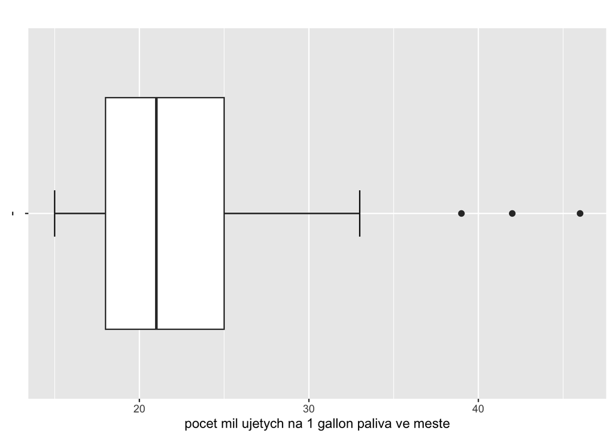

```r
df %>%
  ggplot(aes(x="", y=MPG.city)) +
  stat_boxplot(geom = "errorbar", width = 0.15, coef=1.5) +                  # udělá "tykadla"
  geom_boxplot(outlier.shape = 20, outlier.size = 3) +
  theme(legend.position="right") +
  labs(title= "", x="-", y="pocet mil ujetych na 1 gallon paliva ve meste") +
  theme(plot.title = element_text(face = "bold")) +
  coord_flip()
```

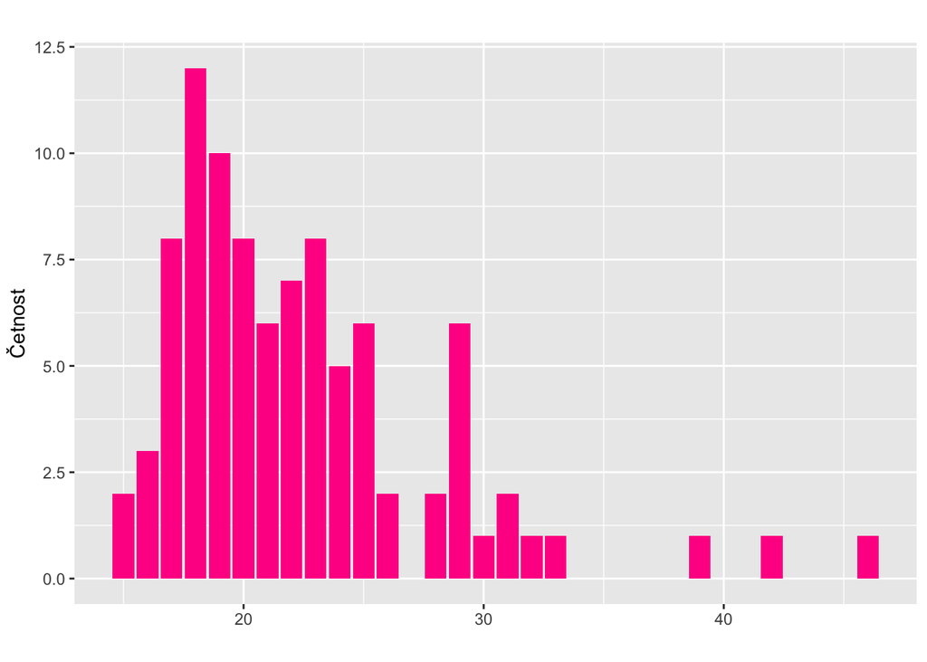

```r
df %>%
  ggplot(aes(x = MPG.city)) +
  geom_bar(fill = "deeppink") +
  labs(title = "", x = "", y = "Četnost") +
  theme(plot.title = element_text(face = "bold"))
```

```r
Q1 <- quantile(df$MPG.city, 0.25)
Q3 <- quantile(df$MPG.city, 0.75)
Q1
```

```
25%
 18
```

```r
Q3
```

```
75%
 25
```

```r
IQR <- Q3 - Q1
IQR
```

```
75%
  7
```

```r
dolni_mez <- Q1 - 1.5 * IQR
horni_mez <- Q3 + 1.5 * IQR
dolni_mez
```

```
25%
7.5
```

```r
horni_mez
```

```
 75%
35.5
```

```r
outliers <- df$MPG.city[df$MPG.city < dolni_mez | df$MPG.city > horni_mez]
outliers
```

```
[1] 46 42 39
```

## Úloha 2

*Spočtěte a interpretujte 99% interval spolehlivosti pro rozdíl váhy amerických a neamerických vozů (Weight a Origin).*

```r
americke_vozy <- subset(df, Origin == "USA")$Weight
neamericke_vozy <- subset(df, Origin != "USA")$Weight
MeanDiffCI(americke_vozy,neamericke_vozy, method="classic", conf.level = 0.99, sides="two.sided")
```

```
 meandiff    lwr.ci    upr.ci
252.97917 -63.80906 569.76740
```

```r
MeanDiffCI(Weight ~ Origin, method = "classic", data = df, conf.level = 0.99, sides="two.sided")
```

```
  meandiff     lwr.ci     upr.ci
-252.97917 -569.76740   63.80906
```

```r
t.test(americke_vozy,neamericke_vozy, conf.level = 0.99)
```

```
    Welch Two Sample t-test

data:  americke_vozy and neamericke_vozy
t = 2.1016, df = 89.825, p-value = 0.03839
alternative hypothesis: true difference in means is not equal to 0
99 percent confidence interval:
 -63.80906 569.76740
sample estimates:
mean of x mean of y
 3195.312  2942.333
```

**Odpověď**:  
Interval spolehlivosti s **1%** hladinou významnosti pro rozdíl váhy amerických a neamerických vozů je **<-63.80906; 569.76740>.** Tento interval **zahrnuje nulu**, takže na hladině významnosti 1% nelze říct, že existuje statisticky významný rozdíl ve váze mezi těmito skupinami. To potvrzuje **t.test**, kde **p-value = 0.03839** je větší než 0.01, tudíž přijmeme nulovou hypotézu, že zde není významný statistický rozdíl.

## Úloha 3

*Můžeme říci, že počet válců se liší u vozů s manuální převodovkou a bez ní? Použijte proměnné Cylinders a Man.trans.avail. Stanovte vhodné hypotézy, které otestujete Fisherovým testem. Ten nemá žádné předpoklady a příkaz pro jeho výpočet v R-ku je `fisher.test(proměnná1, proměnná2)`. Stanovte správné testování hypotézy a vybranou alternativu vložte do příkazu (k dispozici jsou možnosti `"less"`, `"greater"`, `"two.sided"`).*

- **Nulová hypotéza:** Počet válců je nezávislý na dostupnosti manuální převodovky.
- **Alternativní hypotéza:** Počet válců závisí na dostupnosti manuální převodovky.

```r
table(df$Cylinders, df$Man.trans.avail)
```

```
    No Yes
  4  6  46
  6 20  13
  8  6   1
```

```r
fisher.test(df$Cylinders, df$Man.trans.avail, alternative = "two.sided")
```

```
    Fisher's Exact Test for Count Data

data:  df$Cylinders and df$Man.trans.avail
p-value = 7.288e-08
alternative hypothesis: two.sided
```

**Odpověď:**  
**p-value** < 0.05; zamítáme nulovou hypotézu. Přijímáme alternativní hypotézu. Počet válců se liší u vozů s manuální převodovkou a bez ní.

## Úloha 4

*Odhadněte regresní přímku a pomocí lineární regrese zjistěte významnost lineární závislosti počtu mil na jeden gallon paliva na velikosti zavazadlového prostoru (MPG.city, Luggage.room).*

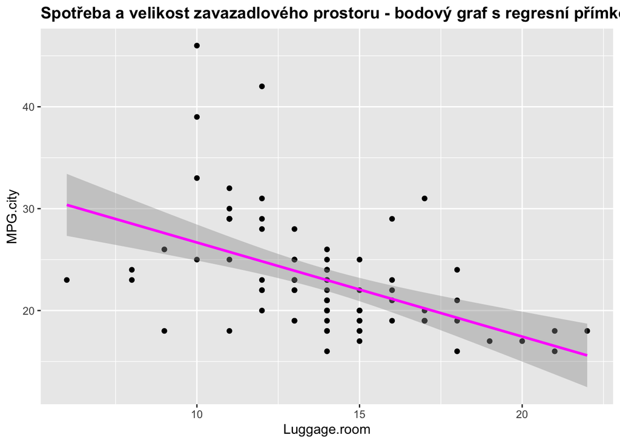

```r
df %>%
  ggplot(aes(x = Luggage.room, y = MPG.city )) +
  geom_point() +
  labs(title = "Spotřeba a velikost zavazadlového prostoru - bodový graf s regresní přímkou", x = "Luggage.room", y = "MPG.city") +
  theme(plot.title = element_text(face = "bold")) +
  geom_smooth(method = "lm", se = TRUE, color = "magenta") # Přidání regresní přímky (parametr lm značí lineární regresi, parametrem se=FALSE nezobrazíme intervaly spolehlivosti)
```

```r
# parametry lm se zadávají v pořadí "závisle proměnná" (u nás na ose y)" ~ "nezávisle proměnná" (u nás na ose x)
regrese <- lm(MPG.city ~ Luggage.room , data = df)
intercept <- coef(regrese)[1]     # Průsečík s osou y
smernice <- coef(regrese)[2]      # Směrnice
cat("Rovnice regresní přímky: MPG.city =", intercept, "+", smernice, "* Luggage.room")
```

```
Rovnice regresní přímky: MPG.city = 35.91134 + -0.9233797 * Luggage.room
```

**Nulová hypotéza**: Neexistuje lineární závislost -vliv proměnné Luggage.room na proměnou MPG.city. hladina významnosti 95%.

```r
summary(regrese)
```

```
Call:
lm(formula = MPG.city ~ Luggage.room, data = df)

Residuals:
    Min      1Q  Median      3Q     Max
-9.6009 -2.9457 -0.9074  1.9777 19.3225

Coefficients:
             Estimate Std. Error t value Pr(>|t|)
(Intercept)   35.9113     2.5751  13.945  < 2e-16 ***
Luggage.room  -0.9234     0.1813  -5.094 2.29e-06 ***
---
Signif. codes:  0 '***' 0.001 '**' 0.01 '*' 0.05 '.' 0.1 ' ' 1

Residual standard error: 4.891 on 80 degrees of freedom
  (11 observations deleted due to missingness)
Multiple R-squared:  0.2449,    Adjusted R-squared:  0.2355
F-statistic: 25.95 on 1 and 80 DF,  p-value: 2.287e-06
```

**Odpověď**:  
**p-value (Pr(>|t|))** < 0.05 ; zamítáme nulovou hypotézu. Proměnná MPG.city je **nepřímo, statisticky významně závislá** na proměnné Luggage.room. (Čím větší velikost zavazadlového prostoru, tím méně vůz ujede mil na 1 gallon paliva ve městě.)

# 3. Část - Úlohy na pravděpodobnostní rozdělení

U každé úlohy student uvede použité pravděpodobnostní rozdělení a výsledek zaokrouhlený na 3 desetinná místa.

## Úloha 1

*V bedně je 40 kusů ovoce, z toho 10 je přezrálých. Náhodně vybereme 8 kusů. Jaká je pravděpodobnost, že mezi vybranými budou maximálně 2 kusy přezrálé?*

```r
round(phyper(2, m = 10, n = 30, k = 8),3)
```

```
[1] 0.688
```

**Hypergeometrické rozdělení, P = 0.688 = 68.8% .**

## Úloha 2

*Při zkoušce na řidičský průkaz uspěje uchazeč s pravděpodobností 75 %. Jaká je pravděpodobnost, že z 12 uchazečů, kteří se zkoušky účastní, uspěje přesně 10 uchazečů?*

```r
round(dbinom(10, size = 12, prob = 0.75),3)
```

```
[1] 0.232
```

**Binomické rozdělení, P = 0.232 = 23.2% .**

## Úloha 3

*Průměrná doba trvání telefonního hovoru je 10 minut. Jaká je pravděpodobnost, že hovor bude trvat mezi 8 a 11 minutami?*

```r
round(pexp(11, rate = 1/10) - pexp(8, rate = 1/10),3)
```

```
[1] 0.116
```

**Exponenciální rozdělení, P = 0.116 = 11.6% .**

## Úloha 4

*IQ skóre v populaci je normálně rozděleno se střední hodnotou 100 a směrodatnou odchylkou 15. Jaká je pravděpodobnost, že náhodně vybraná osoba má IQ vyšší než 130?*

```r
mean <- 100
sd <- 15
round((1 - pnorm(130, mean = mean, sd = sd)),3)
```

```
[1] 0.023
```

**Gaussovské rozdělení, P = 0.023 = 2.3%.**